# Tubes Fundamen Sains Data

kelompok:  
20523164 FAJRUN SHUBHI  
20523181 MUHAMMAD IVANDER RAMUSTA  
20523035 MOCHAMAD FACHRUL ANDRIANSYAH

Clustering sebuah dataset country menggunakan K-MEANS, clustering ini bertujuan untuk mengkategotikan negara menggunakan faktor sosial ekonomi dan kesehatan yang menentukan pembangunan negara secara keseluruhan.  
sumber: kaggle.com

pada dataset ini terdapat 10 columns(atribut) dan 167 baris  
country: nama-nama negara  
child_mort: Kematian anak di bawah usia 5 tahun  
export: Ekspor barang dan jasa per kapita  
healt: Total pengeluaran kesehatan per kapita  
imports: Impor barang dan jasa per kapita  
income: Pendapatan bersih per orang  
inflation: Pengukuran tingkat pertumbuhan tahunan  
life_expec: Jumlah tahun rata-rata seorang anak yang baru lahir akan hidup  
total_fer: Jumlah anak yang akan dilahirkan  
gdpp: PDB per kapita

import dulu library yang akan digunakan untuk clustering k-means

```r
library(tidyverse)
library(cluster)
library(factoextra)
```

```r
library(ggplot2)
```

kemudian import dataset yang akan digunakan dan tampilkan dataset tersebut.

```r
myData <- read.csv("Country-data.csv")
myData
```

```
##                            country child_mort exports health  imports income
## 1                      Afghanistan       90.2  10.000   7.58  44.9000   1610
## 2                          Albania       16.6  28.000   6.55  48.6000   9930
## 3                          Algeria       27.3  38.400   4.17  31.4000  12900
## 4                           Angola      119.0  62.300   2.85  42.9000   5900
## 5              Antigua and Barbuda       10.3  45.500   6.03  58.9000  19100
## 6                        Argentina       14.5  18.900   8.10  16.0000  18700
## 7                          Armenia       18.1  20.800   4.40  45.3000   6700
## 8                        Australia        4.8  19.800   8.73  20.9000  41400
## 9                          Austria        4.3  51.300  11.00  47.8000  43200
## 10                      Azerbaijan       39.2  54.300   5.88  20.7000  16000
## 11                         Bahamas       13.8  35.000   7.89  43.7000  22900
## 12                         Bahrain        8.6  69.500   4.97  50.9000  41100
## 13                      Bangladesh       49.4  16.000   3.52  21.8000   2440
## 14                        Barbados       14.2  39.500   7.97  48.7000  15300
```

[output cut: 321 more lines]

kita bisa lihat 6 data pertama dari dataset dengan perintah head()

```r
head(myData)
```

```
##               country child_mort exports health imports income inflation
## 1         Afghanistan       90.2    10.0   7.58    44.9   1610      9.44
## 2             Albania       16.6    28.0   6.55    48.6   9930      4.49
## 3             Algeria       27.3    38.4   4.17    31.4  12900     16.10
## 4              Angola      119.0    62.3   2.85    42.9   5900     22.40
## 5 Antigua and Barbuda       10.3    45.5   6.03    58.9  19100      1.44
## 6           Argentina       14.5    18.9   8.10    16.0  18700     20.90
##   life_expec total_fer  gdpp
## 1       56.2      5.82   553
## 2       76.3      1.65  4090
## 3       76.5      2.89  4460
## 4       60.1      6.16  3530
## 5       76.8      2.13 12200
## 6       75.8      2.37 10300
```

lakukan perintah berikut untuk melihat statistik dari datasetnya yang ditampilkan percolumn.

```r
summary(myData)
```

```
##    country            child_mort        exports            health
##  Length:167         Min.   :  2.60   Min.   :  0.109   Min.   : 1.810
##  Class :character   1st Qu.:  8.25   1st Qu.: 23.800   1st Qu.: 4.920
##  Mode  :character   Median : 19.30   Median : 35.000   Median : 6.320
##                     Mean   : 38.27   Mean   : 41.109   Mean   : 6.816
##                     3rd Qu.: 62.10   3rd Qu.: 51.350   3rd Qu.: 8.600
##                     Max.   :208.00   Max.   :200.000   Max.   :17.900
##     imports             income         inflation         life_expec
##  Min.   :  0.0659   Min.   :   609   Min.   : -4.210   Min.   :32.10
##  1st Qu.: 30.2000   1st Qu.:  3355   1st Qu.:  1.810   1st Qu.:65.30
##  Median : 43.3000   Median :  9960   Median :  5.390   Median :73.10
##  Mean   : 46.8902   Mean   : 17145   Mean   :  7.782   Mean   :70.56
##  3rd Qu.: 58.7500   3rd Qu.: 22800   3rd Qu.: 10.750   3rd Qu.:76.80
##  Max.   :174.0000   Max.   :125000   Max.   :104.000   Max.   :82.80
##    total_fer          gdpp
##  Min.   :1.150   Min.   :   231
##  1st Qu.:1.795   1st Qu.:  1330
##  Median :2.410   Median :  4660
##  Mean   :2.948   Mean   : 12964
##  3rd Qu.:3.880   3rd Qu.: 14050
##  Max.   :7.490   Max.   :105000
```

bisa juga lakukan perintah str() untuk melihat tipe data tiap columns

```r
str(myData)
```

```
## 'data.frame':    167 obs. of  10 variables:
##  $ country   : chr  "Afghanistan" "Albania" "Algeria" "Angola" ...
##  $ child_mort: num  90.2 16.6 27.3 119 10.3 14.5 18.1 4.8 4.3 39.2 ...
##  $ exports   : num  10 28 38.4 62.3 45.5 18.9 20.8 19.8 51.3 54.3 ...
##  $ health    : num  7.58 6.55 4.17 2.85 6.03 8.1 4.4 8.73 11 5.88 ...
##  $ imports   : num  44.9 48.6 31.4 42.9 58.9 16 45.3 20.9 47.8 20.7 ...
##  $ income    : int  1610 9930 12900 5900 19100 18700 6700 41400 43200 16000 ...
##  $ inflation : num  9.44 4.49 16.1 22.4 1.44 20.9 7.77 1.16 0.873 13.8 ...
##  $ life_expec: num  56.2 76.3 76.5 60.1 76.8 75.8 73.3 82 80.5 69.1 ...
##  $ total_fer : num  5.82 1.65 2.89 6.16 2.13 2.37 1.69 1.93 1.44 1.92 ...
##  $ gdpp      : int  553 4090 4460 3530 12200 10300 3220 51900 46900 5840 ...
```

```r
myData.new <- as.data.frame(myData) # Transforming our main data in a data frame
myData.new <- myData[,-1]
myData.new
```

```
##     child_mort exports health  imports income inflation life_expec total_fer
## 1         90.2  10.000   7.58  44.9000   1610     9.440       56.2      5.82
## 2         16.6  28.000   6.55  48.6000   9930     4.490       76.3      1.65
## 3         27.3  38.400   4.17  31.4000  12900    16.100       76.5      2.89
## 4        119.0  62.300   2.85  42.9000   5900    22.400       60.1      6.16
## 5         10.3  45.500   6.03  58.9000  19100     1.440       76.8      2.13
## 6         14.5  18.900   8.10  16.0000  18700    20.900       75.8      2.37
## 7         18.1  20.800   4.40  45.3000   6700     7.770       73.3      1.69
## 8          4.8  19.800   8.73  20.9000  41400     1.160       82.0      1.93
## 9          4.3  51.300  11.00  47.8000  43200     0.873       80.5      1.44
## 10        39.2  54.300   5.88  20.7000  16000    13.800       69.1      1.92
## 11        13.8  35.000   7.89  43.7000  22900    -0.393       73.8      1.86
## 12         8.6  69.500   4.97  50.9000  41100     7.440       76.0      2.16
## 13        49.4  16.000   3.52  21.8000   2440     7.140       70.4      2.33
## 14        14.2  39.500   7.97  48.7000  15300     0.321       76.7      1.78
```

[output cut: 321 more lines]

membuat histogram dari masing-masing atribut.

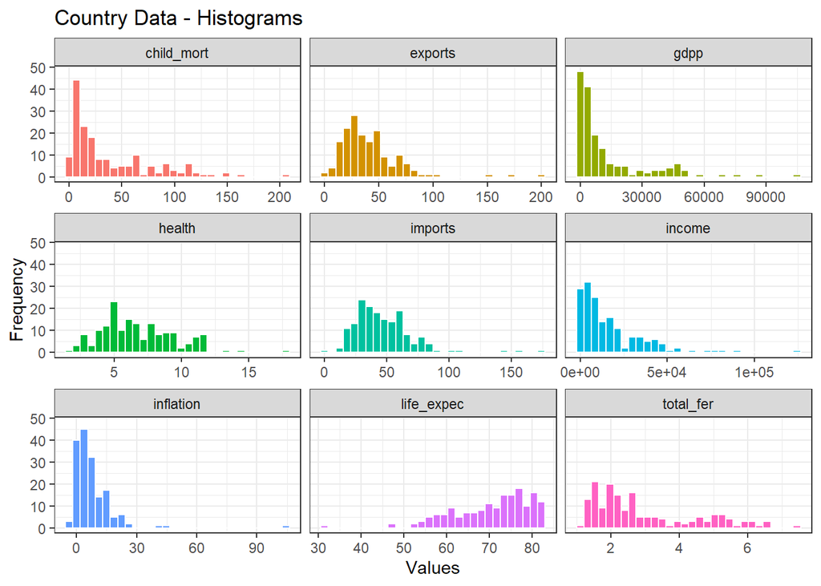

```r
myData.new %>%
  gather(Attributes, value, 1:9) %>%
  ggplot(aes(x=value, fill=Attributes)) +
  geom_histogram(colour="white", show.legend=FALSE) +
  facet_wrap(~Attributes, scales="free_x") +
  labs(x="Values", y="Frequency",
       title="Country Data - Histograms") +
  theme_bw()
```

Mencari K(jumlah cluster) yang Optimal

Dalam menentukan k pada cluster, ada beberapa pendekatan yang dapat digunakan yaitu : 1. Silhouette 2. Elbow 3. Gap Statistic

disini kami mencoba untuk menggunakan metode elbow, Berdasarkan grafik dibawah, terlihat penurunan paling tajam membentuk elbow atau mementuk siku pada k=2. Sehingga untuk metode elbow diperoleh hasil k optimal 2

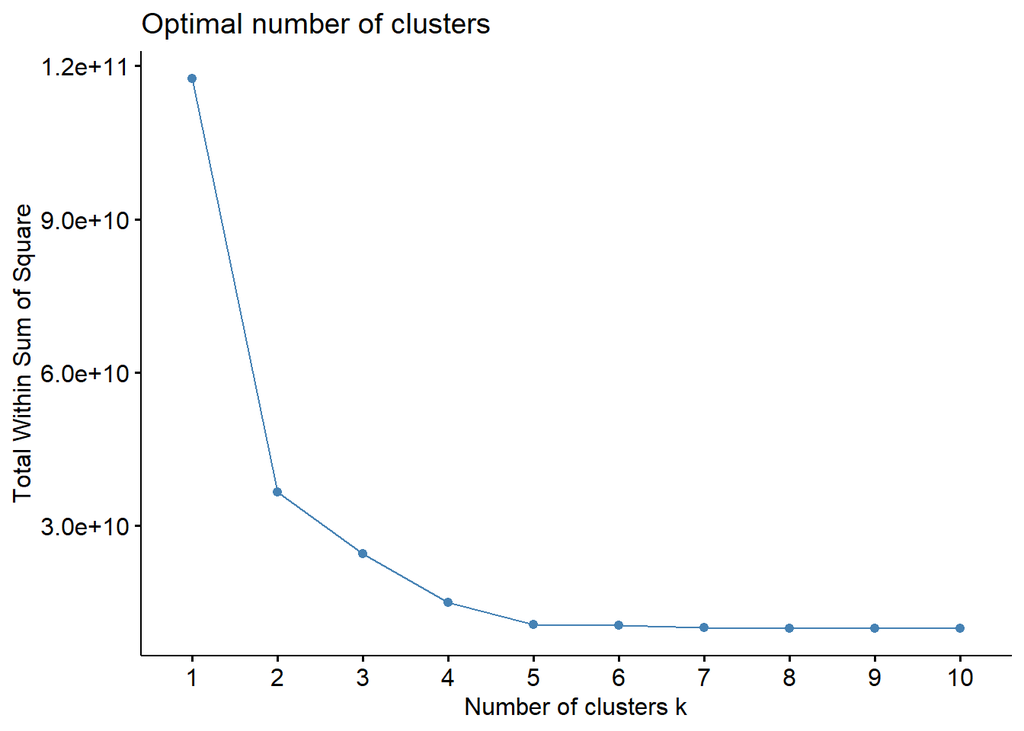

```r
fviz_nbclust(myData.new, kmeans, method = "wss")
```

kami juga mencoba dengan menggunakan metode silhouette

Pendekatan silhouette menggunakan rata-rata nilai cluster untuk menduga nilai k optimum. Semakin tinggi nilai rata-ratanya maka akan semakin baik clusternya. Berdasarkan grafik silhouette yang terbentuk, diperoleh banyak cluster optimal seanyak 2. Hasil ini sama dengan penentuan k optimal menggunakan metode elbow

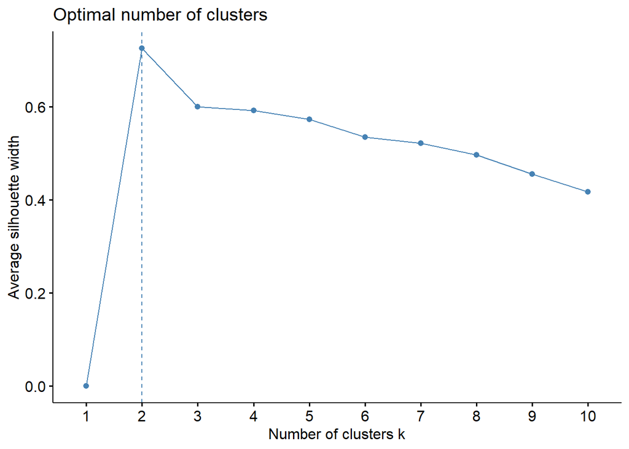

```r
fviz_nbclust(myData.new, kmeans, method = "silhouette")
```

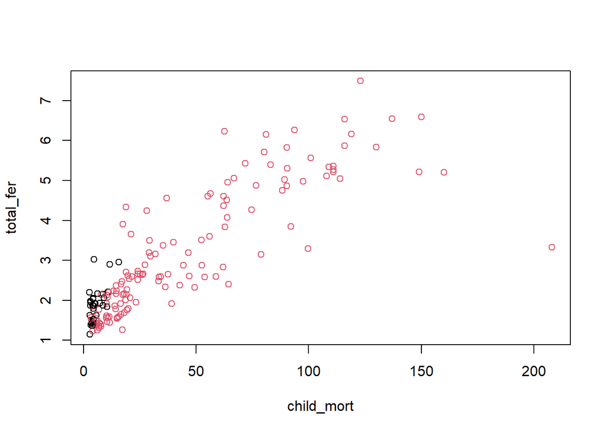

```r
set.seed(123)
result <- kmeans(myData.new, centers = 2, nstart = 25)

plot(myData.new[,c(1,8)], col=result$cluster)
```

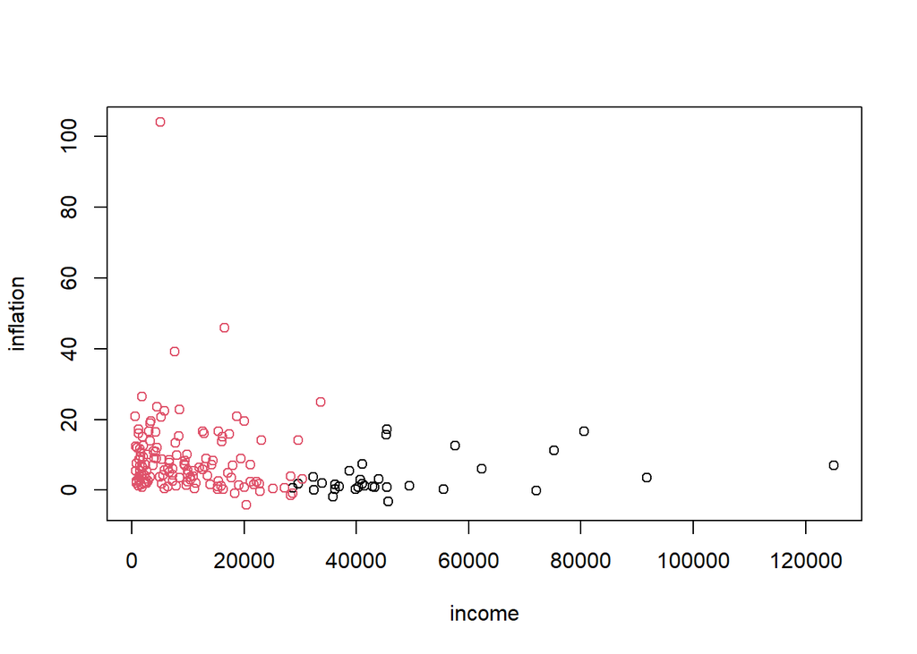

```r
plot(myData.new[,c(5,6)], col=result$cluster)
```

Visualisasi menggunakan ggplot2

Di bawah ini, kita akan memvisualisasikan hasil clustering di atas, menggunakan package ggplot2. Baris ke-1 menjadikan tipe data cluster dari numerik ke diskret (kategori/factor)

```r
myData.new$cluster <- factor(result$cluster)
centers <- as.data.frame(result$centers)
```

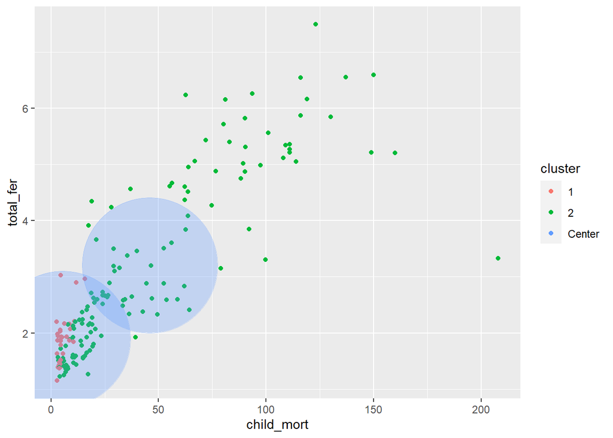

```r
ggplot() +
  geom_point(data=myData.new, aes(x=child_mort, y=total_fer,color=cluster))  +
  geom_point(data=centers, aes(x=child_mort, y=total_fer, color="Center"),
             size=52, alpha=.3, show.legend = FALSE)
```

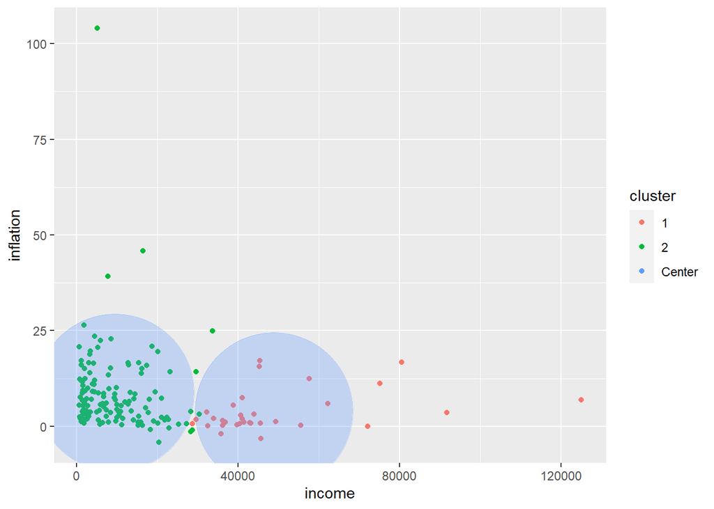

```r
ggplot() +
  geom_point(data=myData.new, aes(x=income, y=inflation,color=cluster))  +
  geom_point(data=centers, aes(x=income, y=inflation, color="Center"),
             size=52, alpha=.3, show.legend = FALSE)
```

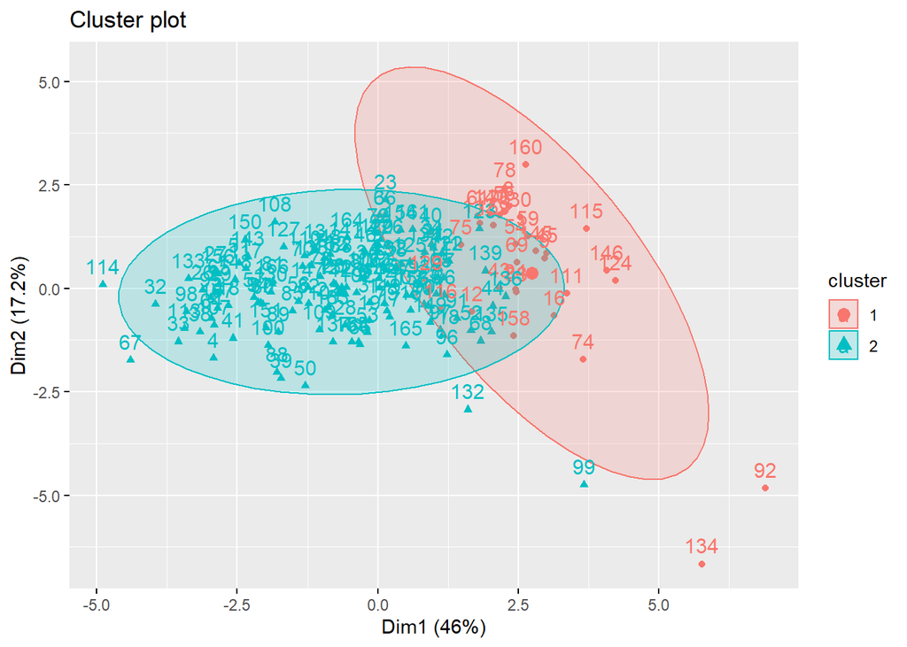

```r
fviz_cluster(result, myData[, -1], ellipse.type = "norm")
```

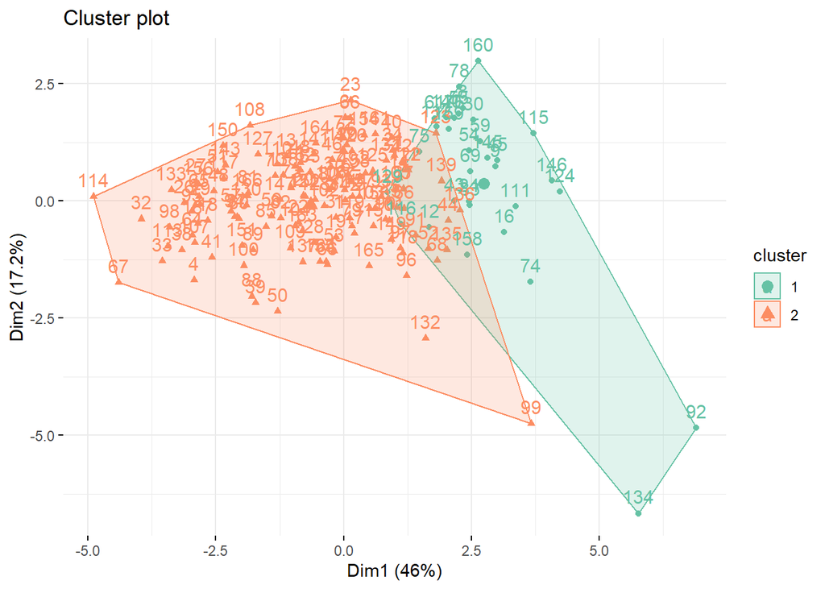

```r
fviz_cluster(result, myData[, -1],
   palette = "Set2", ggtheme = theme_minimal())
```

Untuk melihat nilai apa saja yang dikembalikan oleh fungsi kmeans, dapat dilihat melalui

```r
attributes(result)$names
```

```
## [1] "cluster"      "centers"      "totss"        "withinss"     "tot.withinss"
## [6] "betweenss"    "size"         "iter"         "ifault"
```

dan untuk memanggil nilai tertentu di atas, dapat dilakukan dengan cara result$cluster, result$centers, result$size, dan seterusnya

```r
# Clusters to which each point is associated
result$cluster
```

```
##   [1] 2 2 2 2 2 2 2 1 1 2 2 1 2 2 2 1 2 2 2 2 2 2 2 1 2 2 2 2 2 1 2 2 2 2 2 2 2
##  [38] 2 2 2 2 2 1 2 1 2 2 2 2 2 2 2 2 1 1 2 2 2 1 2 1 2 2 2 2 2 2 2 1 2 2 2 2 1
##  [75] 1 1 2 1 2 2 2 2 1 2 2 2 2 2 2 2 2 1 2 2 2 2 2 2 2 2 2 2 2 2 2 2 2 2 2 2 1
## [112] 1 2 2 1 1 2 2 2 2 2 2 2 1 2 2 2 2 1 2 2 2 2 1 2 2 2 2 2 1 2 2 2 2 1 1 2 2
## [149] 2 2 2 2 2 2 2 2 2 1 1 1 2 2 2 2 2 2 2
```

```r
# Cluster centers
result$centers
```

```
##   child_mort  exports   health  imports    income inflation life_expec
## 1    5.59375 55.96875 8.483750 46.45937 48962.500  3.852000   80.09687
## 2   46.01556 37.58666 6.420296 46.99234  9602.689  8.713348   68.29407
##   total_fer      gdpp
## 1  1.889688 45090.625
## 2  3.198815  5348.993
```

```r
# Cluster Size
result$size
```

```
## [1]  32 135
```

```r
# Between clusters sum of square
result$betweenss
```

```
## [1] 80931299535
```

```r
# Total with sum of square
result$tot.withinss
```

```
## [1] 36528387934
```

kami mencoba untuk melakukan clustering dengan membagi menjadi lebih dari 2 cluster, disini kami mencoba untuk 3 cluster, 4 cluster dan 5 cluster, dan menyimpannya pada suatu variable

```r
result_3 <- kmeans(myData.new, centers = 3, nstart = 25)
result_4 <- kmeans(myData.new, centers = 4, nstart = 25)
result_5 <- kmeans(myData.new, centers = 5, nstart = 25)
```

kemudian kita melakukan clustering dengan menggunakan fviz_cluster dan memasukan variable tadi kemudian lakukan ploting.

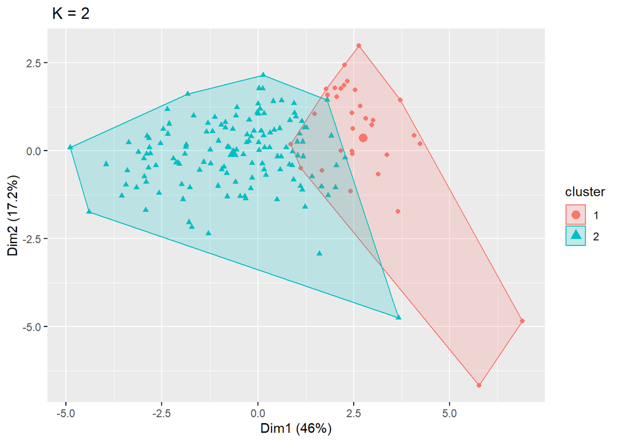

```r
p1 <- fviz_cluster(result, geom = "point", data = myData[,-1]) + ggtitle(" K = 2")
plot(p1)
```

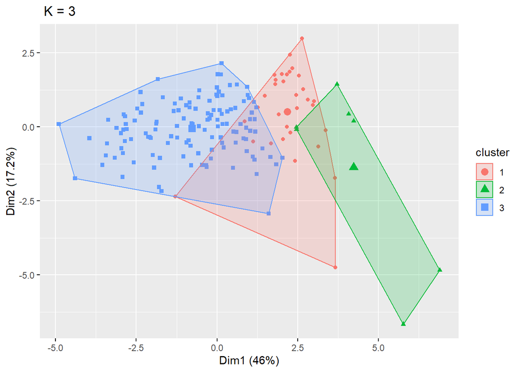

```r
p2 <- fviz_cluster(result_3, geom = "point", data = myData[,-1]) + ggtitle(" K = 3")
plot(p2)
```

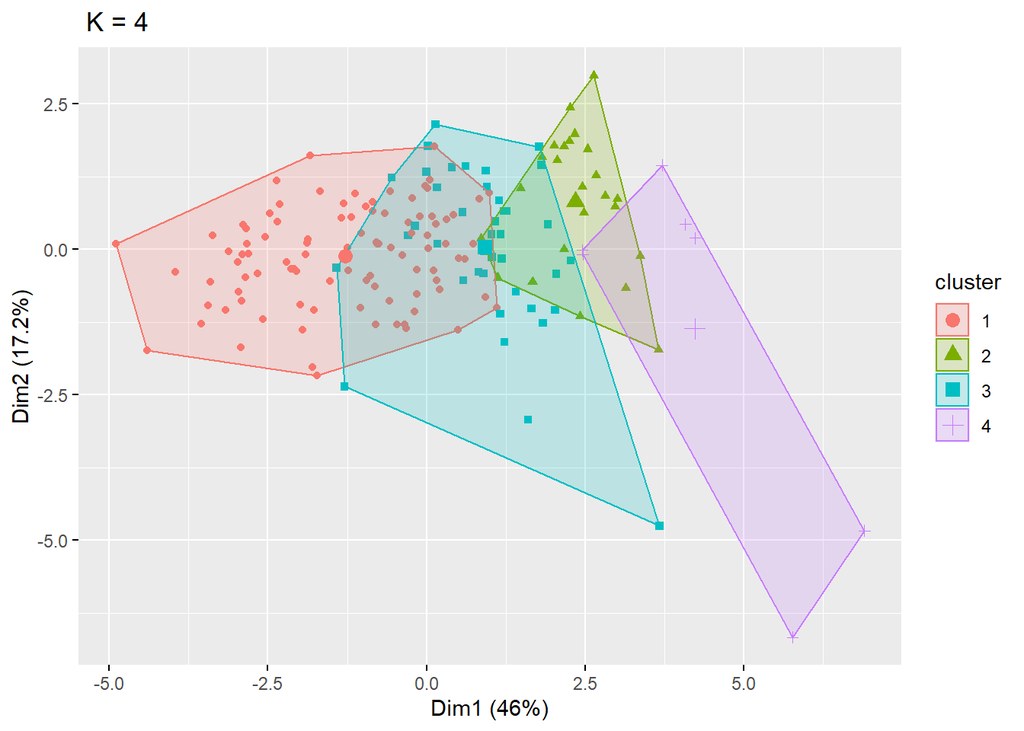

```r
p3 <- fviz_cluster(result_4, geom = "point", data = myData[-1]) + ggtitle(" K = 4")
plot(p3)
```

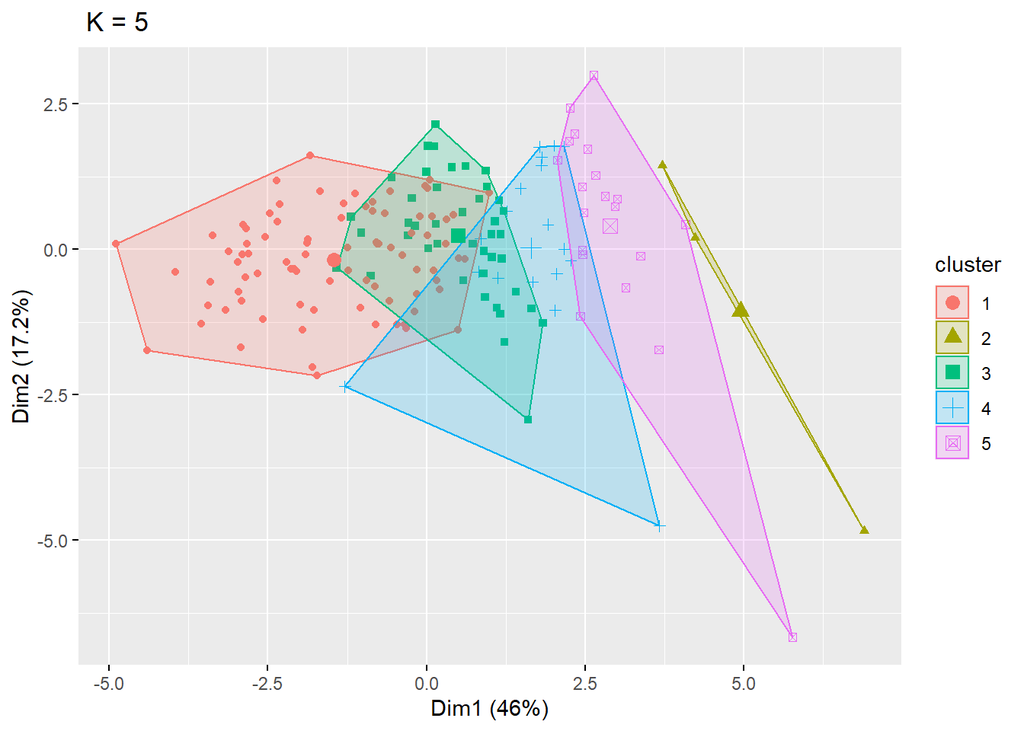

```r
p4 <- fviz_cluster(result_5, geom = "point", data = myData[-1]) + ggtitle(" K = 5")
plot(p4)
```

Hasil plot diatas merupakan clustering datasets country dengan membagi menjadi 2, 3, 4, 5 cluster.

Terimakasih…………..